# EDA of Red Wine Quality Dataset by Iwan Thomas

# Introduction

In this analysis, I will explore a dataset of 1599 individual red wines with the aim of determining what chemical properties influence their quality. I will perform this analysis in R. Each individual wine is described by:

- a unique identifier
- 11 chemical properties
- an expert quality score, where 0 is very bad and 10 is very excellent.

The data used was from the following source:

- P. Cortez, A. Cerdeira, F. Almeida, T. Matos and J. Reis.
- Modeling wine preferences by data mining from physicochemical properties.
- In Decision Support Systems, Elsevier, 47(4):547-553. ISSN: 0167-9236.

The original dataset can be found [here](https://www.google.com/url?q=https://s3.amazonaws.com/udacity-hosted-downloads/ud651/wineQualityReds.csv&sa=D&ust=1472652941026000&usg=AFQjCNH7NX-Zos0LE3pSojCeMI66wf7j3Q) and a description of the variables and how the data was collected can be found [here](https://s3.amazonaws.com/udacity-hosted-downloads/ud651/wineQualityInfo.txt).

I will first load and inspect the dataset.

```
## 'data.frame':    1599 obs. of  13 variables:
##  $ X                   : int  1 2 3 4 5 6 7 8 9 10 ...
##  $ fixed.acidity       : num  7.4 7.8 7.8 11.2 7.4 7.4 7.9 7.3 7.8 7.5 ...
##  $ volatile.acidity    : num  0.7 0.88 0.76 0.28 0.7 0.66 0.6 0.65 0.58 0.5 ...
##  $ citric.acid         : num  0 0 0.04 0.56 0 0 0.06 0 0.02 0.36 ...
##  $ residual.sugar      : num  1.9 2.6 2.3 1.9 1.9 1.8 1.6 1.2 2 6.1 ...
##  $ chlorides           : num  0.076 0.098 0.092 0.075 0.076 0.075 0.069 0.065 0.073 0.071 ...
##  $ free.sulfur.dioxide : num  11 25 15 17 11 13 15 15 9 17 ...
##  $ total.sulfur.dioxide: num  34 67 54 60 34 40 59 21 18 102 ...
##  $ density             : num  0.998 0.997 0.997 0.998 0.998 ...
##  $ pH                  : num  3.51 3.2 3.26 3.16 3.51 3.51 3.3 3.39 3.36 3.35 ...
##  $ sulphates           : num  0.56 0.68 0.65 0.58 0.56 0.56 0.46 0.47 0.57 0.8 ...
##  $ alcohol             : num  9.4 9.8 9.8 9.8 9.4 9.4 9.4 10 9.5 10.5 ...
##  $ quality             : int  5 5 5 6 5 5 5 7 7 5 ...
```

```
##        X          fixed.acidity   volatile.acidity  citric.acid
##  Min.   :   1.0   Min.   : 4.60   Min.   :0.1200   Min.   :0.000
##  1st Qu.: 400.5   1st Qu.: 7.10   1st Qu.:0.3900   1st Qu.:0.090
##  Median : 800.0   Median : 7.90   Median :0.5200   Median :0.260
##  Mean   : 800.0   Mean   : 8.32   Mean   :0.5278   Mean   :0.271
##  3rd Qu.:1199.5   3rd Qu.: 9.20   3rd Qu.:0.6400   3rd Qu.:0.420
##  Max.   :1599.0   Max.   :15.90   Max.   :1.5800   Max.   :1.000
##  residual.sugar     chlorides       free.sulfur.dioxide
##  Min.   : 0.900   Min.   :0.01200   Min.   : 1.00
##  1st Qu.: 1.900   1st Qu.:0.07000   1st Qu.: 7.00
##  Median : 2.200   Median :0.07900   Median :14.00
##  Mean   : 2.539   Mean   :0.08747   Mean   :15.87
##  3rd Qu.: 2.600   3rd Qu.:0.09000   3rd Qu.:21.00
##  Max.   :15.500   Max.   :0.61100   Max.   :72.00
##  total.sulfur.dioxide    density             pH          sulphates
##  Min.   :  6.00       Min.   :0.9901   Min.   :2.740   Min.   :0.3300
##  1st Qu.: 22.00       1st Qu.:0.9956   1st Qu.:3.210   1st Qu.:0.5500
##  Median : 38.00       Median :0.9968   Median :3.310   Median :0.6200
##  Mean   : 46.47       Mean   :0.9967   Mean   :3.311   Mean   :0.6581
##  3rd Qu.: 62.00       3rd Qu.:0.9978   3rd Qu.:3.400   3rd Qu.:0.7300
##  Max.   :289.00       Max.   :1.0037   Max.   :4.010   Max.   :2.0000
##     alcohol         quality
##  Min.   : 8.40   Min.   :3.000
##  1st Qu.: 9.50   1st Qu.:5.000
##  Median :10.20   Median :6.000
##  Mean   :10.42   Mean   :5.636
##  3rd Qu.:11.10   3rd Qu.:6.000
##  Max.   :14.90   Max.   :8.000
```

The data is tidy and clean. The only surprise I noted was 132 wines with citric acid values of zero.

Let’s first look at the distributions of all of our properties. Some of the plots are right-skewed and a logarithmic transformation of the x-axis was applied to further explore the variable’s distribution.

# Univariate Plots Section

Let’s look at the distributions of all variables. Relevant statistics are included at the end of each plot.

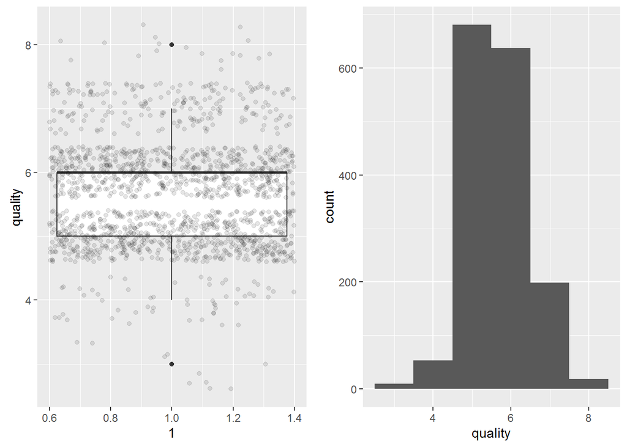

```
##    Min. 1st Qu.  Median    Mean 3rd Qu.    Max.
##   3.000   5.000   6.000   5.636   6.000   8.000
```

We see that wine quality is approximately normally distributed with a mean value of 5.6.

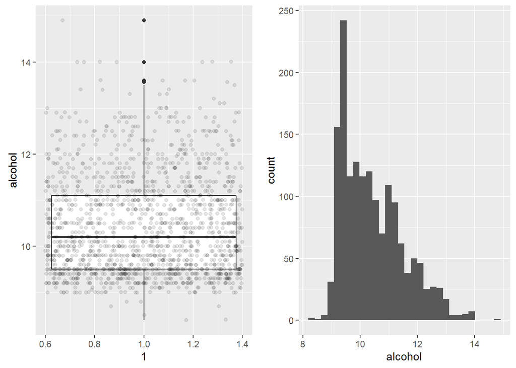

```
##    Min. 1st Qu.  Median    Mean 3rd Qu.    Max.
##    8.40    9.50   10.20   10.42   11.10   14.90
```

The alcohol distribution is right-skewed. It will be interesting to see whether different quality wines have distinct alcohol content.

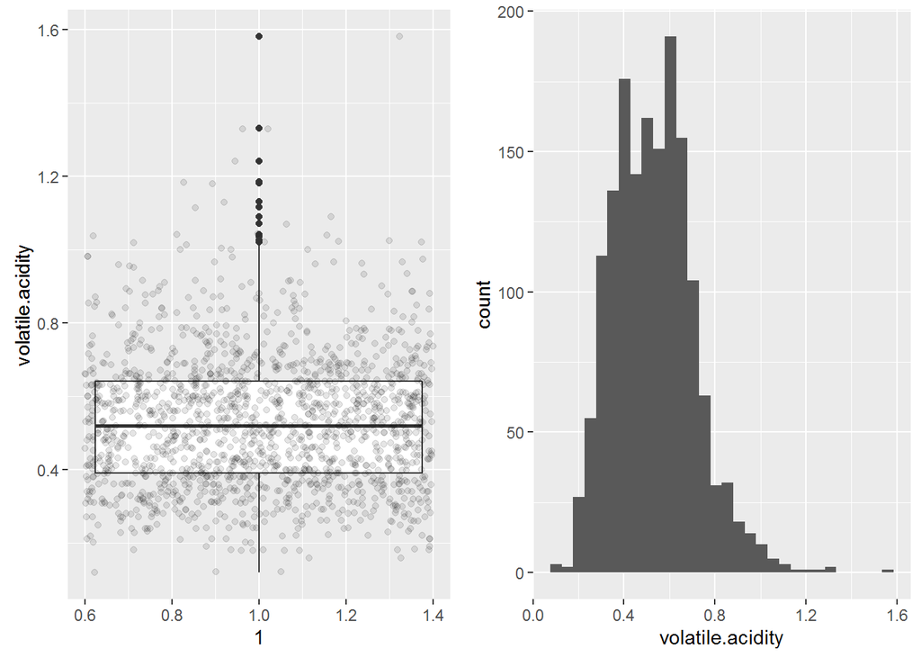

```
##    Min. 1st Qu.  Median    Mean 3rd Qu.    Max.
##  0.1200  0.3900  0.5200  0.5278  0.6400  1.5800
```

Volatile acidity has quite a few outliers with high values. Which wines do these values belong to?

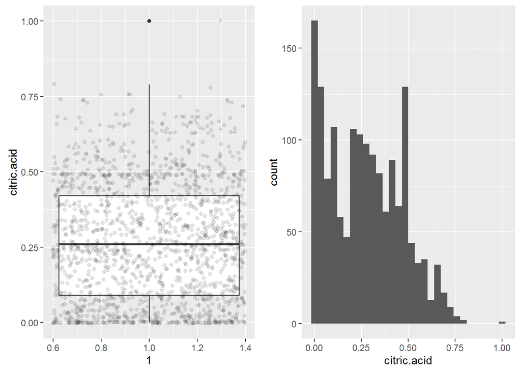

```
##    Min. 1st Qu.  Median    Mean 3rd Qu.    Max.
##   0.000   0.090   0.260   0.271   0.420   1.000
```

I have doubts about the validity of the citric acid data, because of the numbers of wines with citric acid = 0.

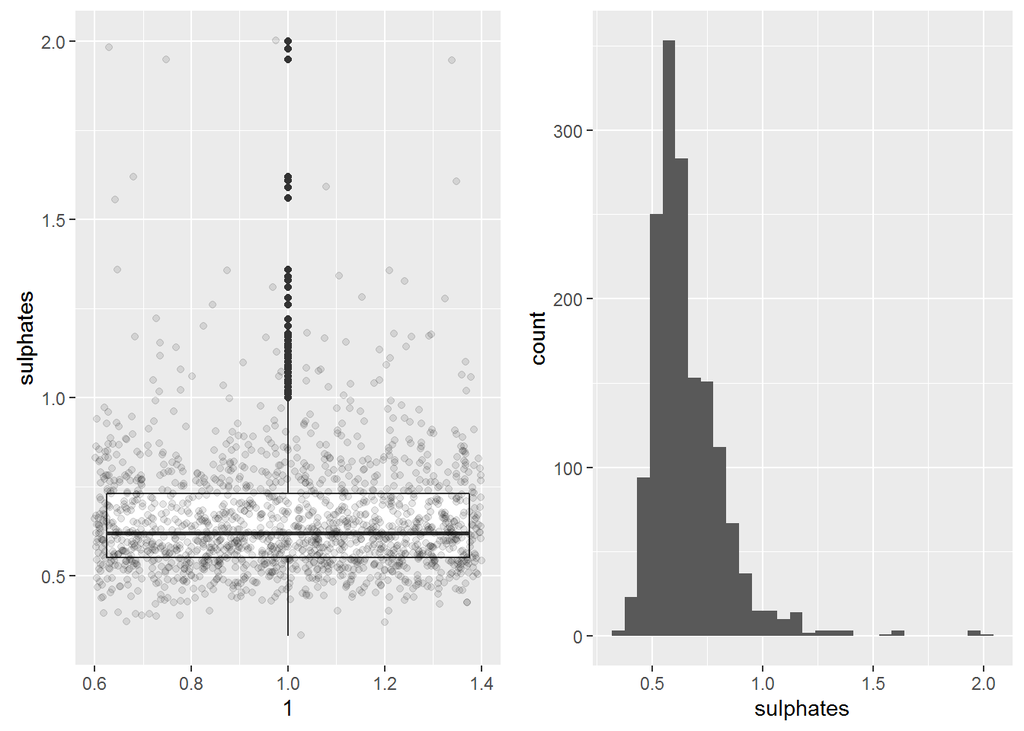

```
##    Min. 1st Qu.  Median    Mean 3rd Qu.    Max.
##  0.3300  0.5500  0.6200  0.6581  0.7300  2.0000
```

The sulphates distribution is quite tight with a mean of 0.66. I’m interested in understanding whether the outlying data point belong to good, average or bad wines.

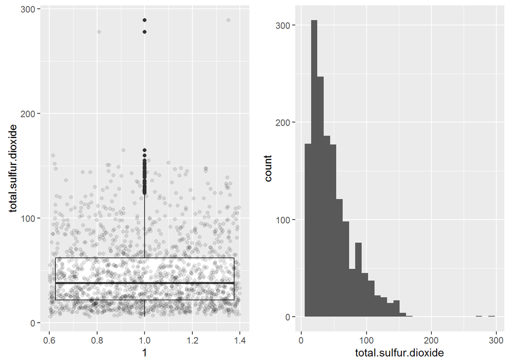

```
##    Min. 1st Qu.  Median    Mean 3rd Qu.    Max.
##    6.00   22.00   38.00   46.47   62.00  289.00
```

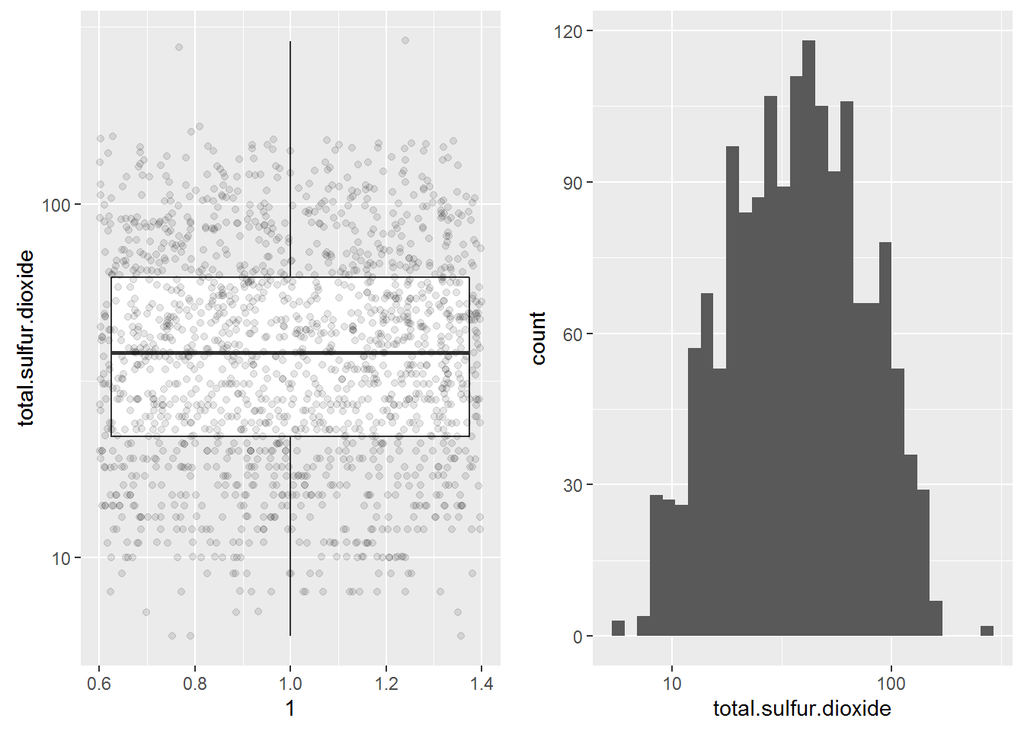

Applying a log transformation helps normalise the distribution.

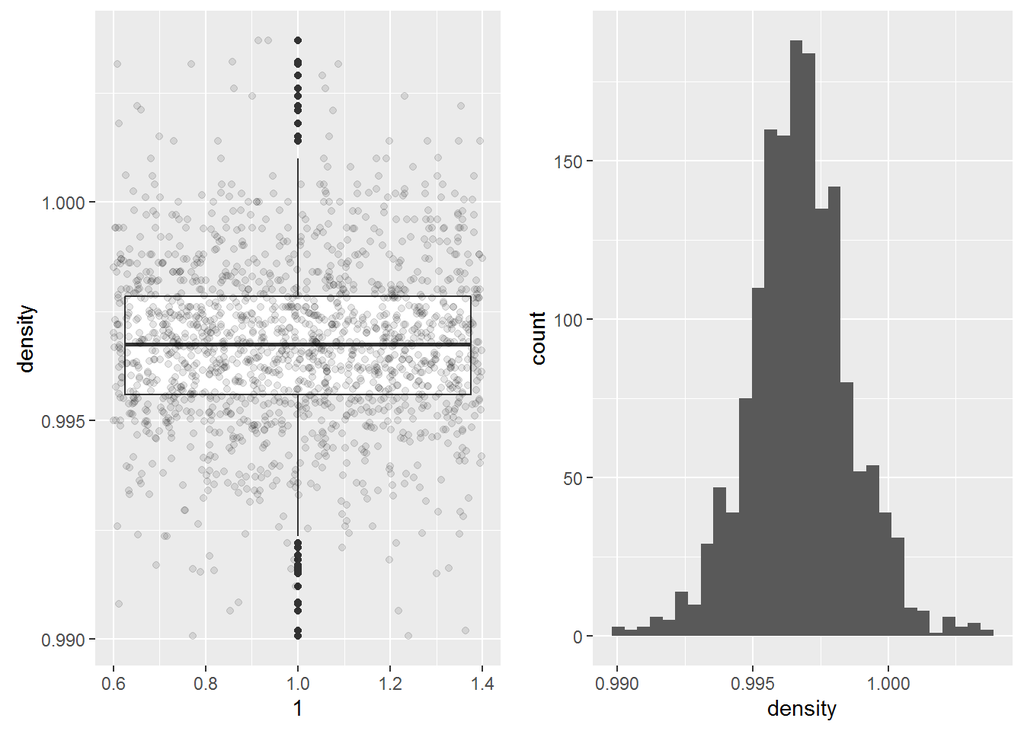

```
##    Min. 1st Qu.  Median    Mean 3rd Qu.    Max.
##  0.9901  0.9956  0.9968  0.9967  0.9978  1.0040
```

We have a very tight distribution with a very small range. This comes as no surprise - each wine is mainly water!

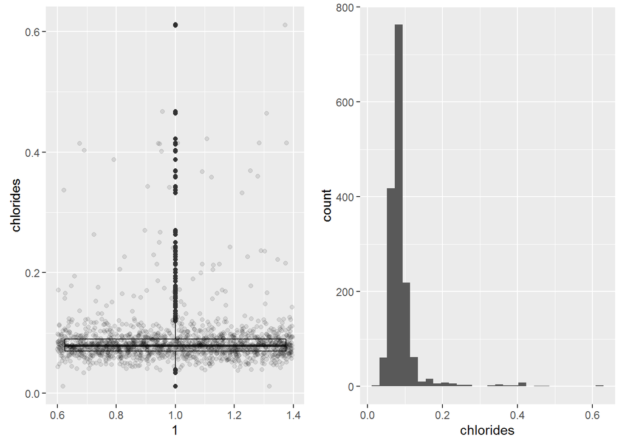

```
##    Min. 1st Qu.  Median    Mean 3rd Qu.    Max.
## 0.01200 0.07000 0.07900 0.08747 0.09000 0.61100
```

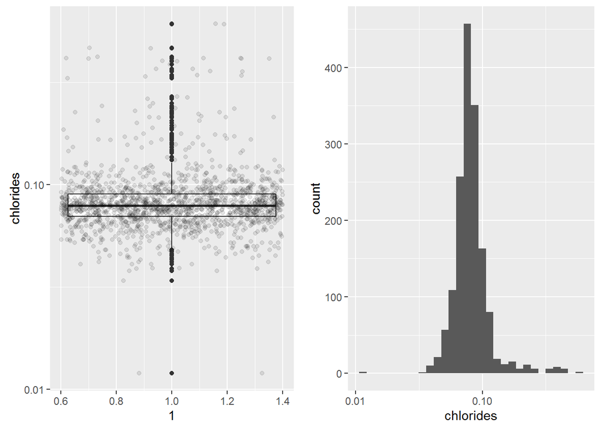

The distribution is right-skewed. Applying a log transformation helps normalise this.

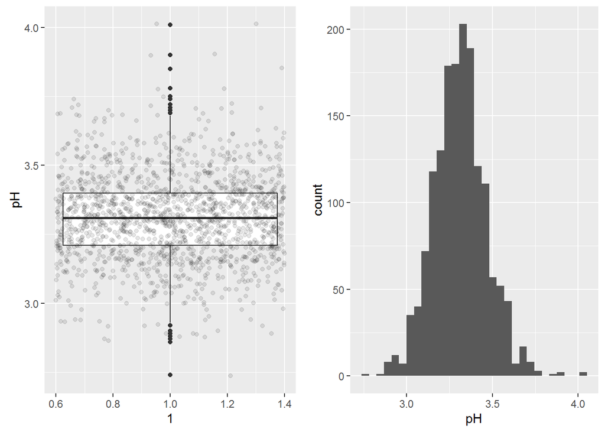

```
##    Min. 1st Qu.  Median    Mean 3rd Qu.    Max.
##   2.740   3.210   3.310   3.311   3.400   4.010
```

The pH is normally distributed. I am somewhat surprised by the range of values observed. As with all the variables, it will be interesting to draw out commonalities and differences between wine groups.

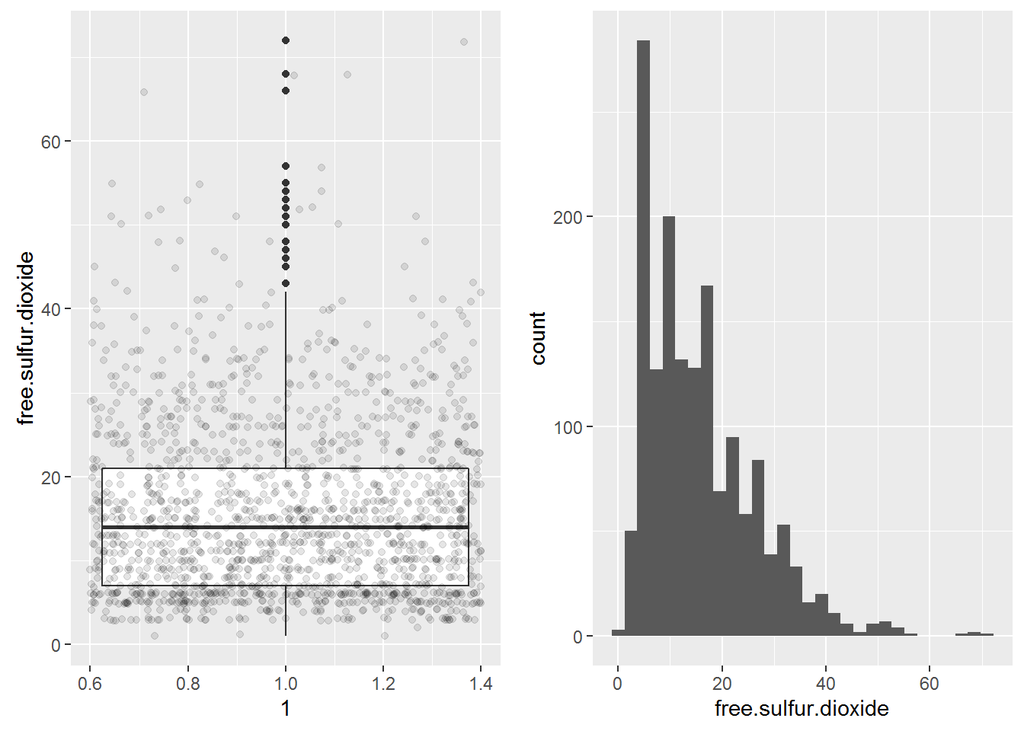

```
##    Min. 1st Qu.  Median    Mean 3rd Qu.    Max.
##    1.00    7.00   14.00   15.87   21.00   72.00
```

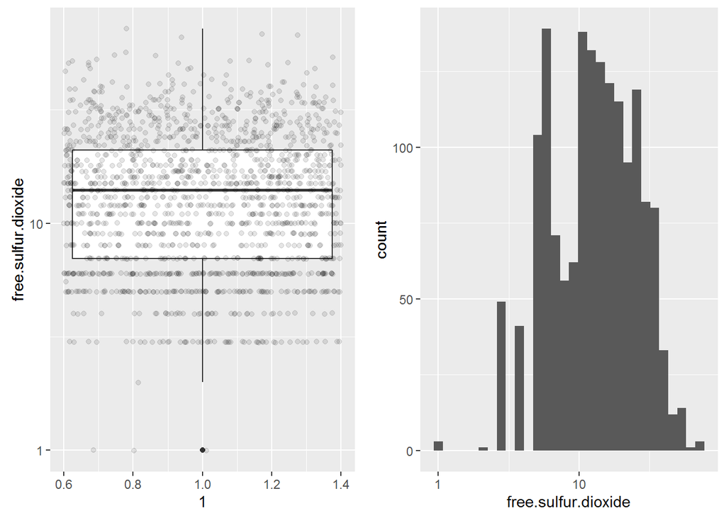

A similar distribution to the total sulfur dioxide content. Another log transformation applied to transform and further investigate a right-skewed distribution. I wonder why the values seem so discrete?

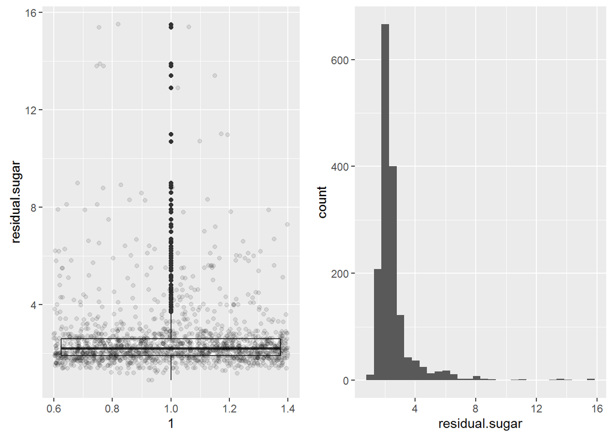

```
##    Min. 1st Qu.  Median    Mean 3rd Qu.    Max.
##   0.900   1.900   2.200   2.539   2.600  15.500
```

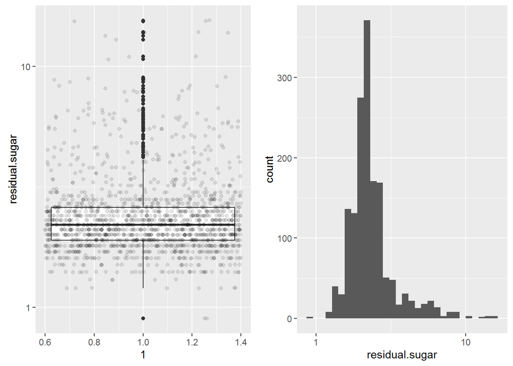

There are many outliers with high residual sugar. I wonder whether these are good or bad wines? Log transformation applied to second figure.

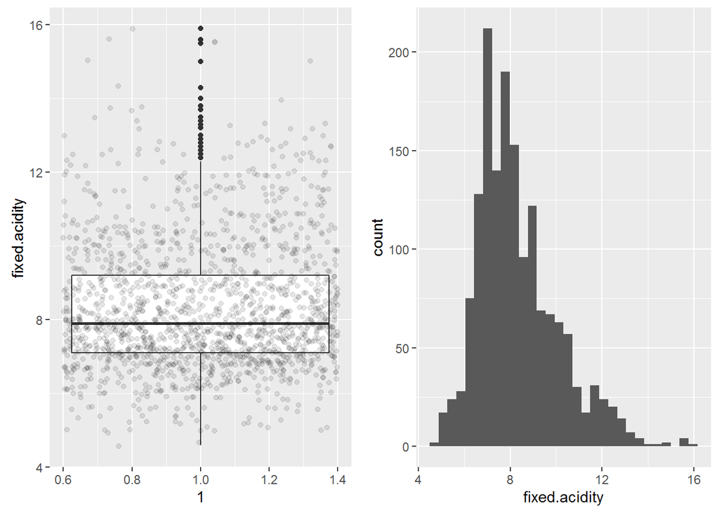

```
##    Min. 1st Qu.  Median    Mean 3rd Qu.    Max.
##    4.60    7.10    7.90    8.32    9.20   15.90
```

# Univariate Analysis

### What is the structure of your dataset?

There are 1599 observations of 13 variables. Each wine is assigned an integer id value, 11 numerical chemical properties of wine are recorded, and the wine is awarded a quality rating.

### What is/are the main feature(s) of interest in your dataset?

The main feature of interest is the quality rating. I will investigate the relationship between various chemical properties and the quality of the wine.

### What other features in the dataset do you think will help support your investigation into your feature(s) of interest?

Investigating how other variables are related may offer further insights into what makes a wine good.

### Did you create any new variables from existing variables in the dataset?

Not yet, but I will group the quality ratings into three categories: bad, average and good.

### Of the features you investigated, were there any unusual distributions? Did you perform any operations on the data to tidy, adjust, or change the form of the data? If so, why did you do this?

The loaded dataset was already tidy.

# Bivariate Plots Section

I will begin this section with a visualization of the correlation values between each feature in the data set, that can be used to guide and focus the following analysis.

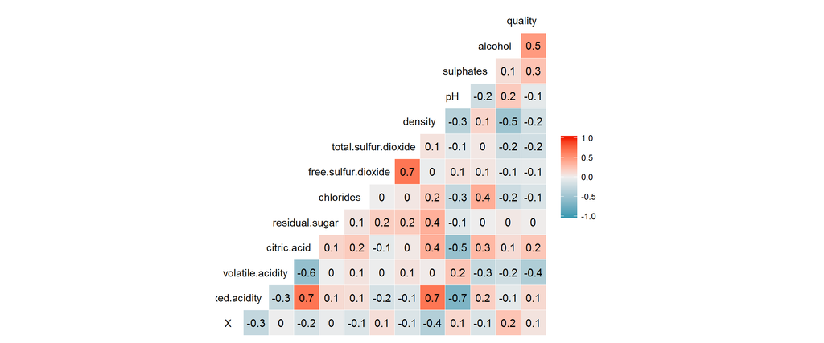

This shows the variables that correlate most highly with quality. These are:

- alcohol (positive correlation)
- volatile.acidity (negative correlation)
- sulphates (positive correlation)
- citric.acid (positive correlation)
- total.sulfur.dioxide (negative correlation)
- density (negative correlation)

It also reveals other correlations that might be worth investigating, such as :

- alcohol vs density is correlated as expected. It might be interesting to see how residual sugar affects that.
- fixed acidity and density are highly correlated.
- chlorides and sulphates
- citric and fixed acid show a strong correlation with pH. This comes as no surprise.
- There are strong correlations between volatile acidity and citric acid & fixed acidity and citric acid. This might be interesting to compare and contrast between wines of different qualities.

Funnily, the quality is correlated, albeit only slightly with the number assigned to each wine. Perhaps the wine tasters got drunk during the tasting?

Let’s now plot scatterplots of quality vs a number of chemical properties. To make the plots more informative, boxplots and trendlines are also included. Below each plot, the correlation coefficient is included.

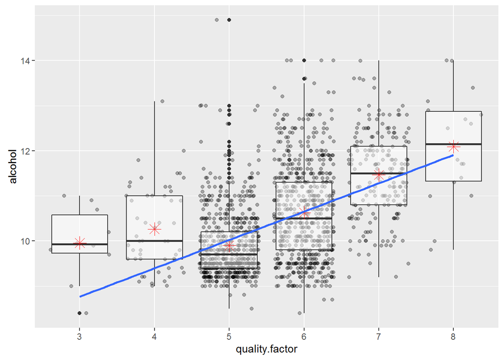

```
## [1] 0.4761663
```

A trend of increasing alcohol content in higher quality wines is observed. Alcohol is the chemical property that correlates most with quality, with r = 0.47.

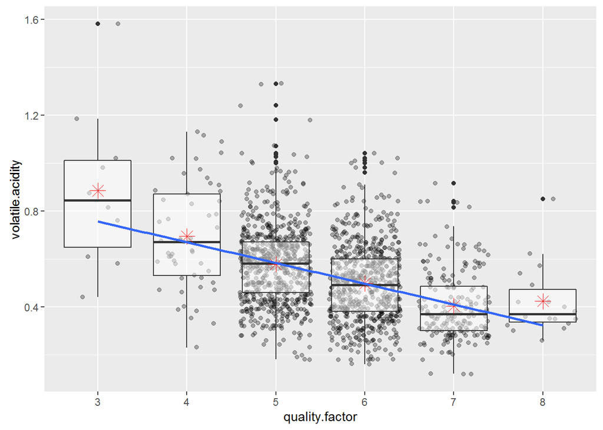

```
## [1] -0.3905578
```

Volatile acidity and quality are negatively correlated. We also see the IQR for volatile acidity decrease as the wine quality increases.

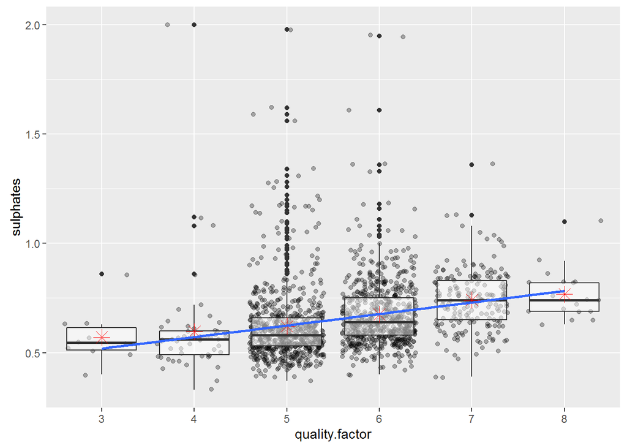

```
## [1] 0.2513971
```

Sulphates and quality are correlated. There are many outliers for this distribution.

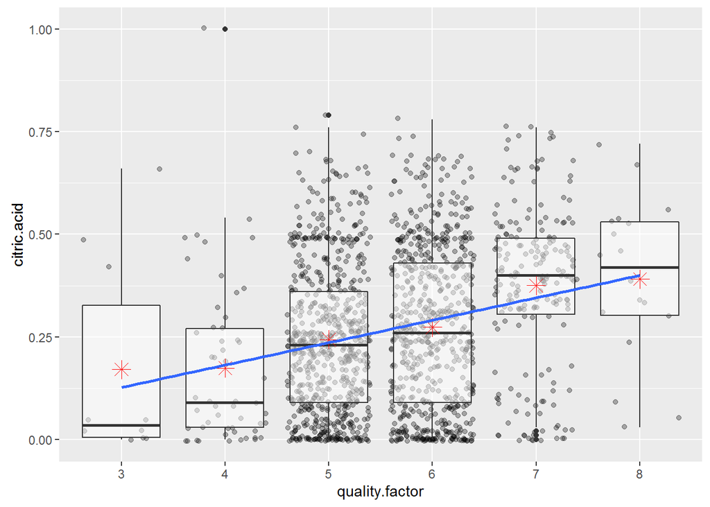

```
## [1] 0.2263725
```

Citric acid and quality are positively correlated.

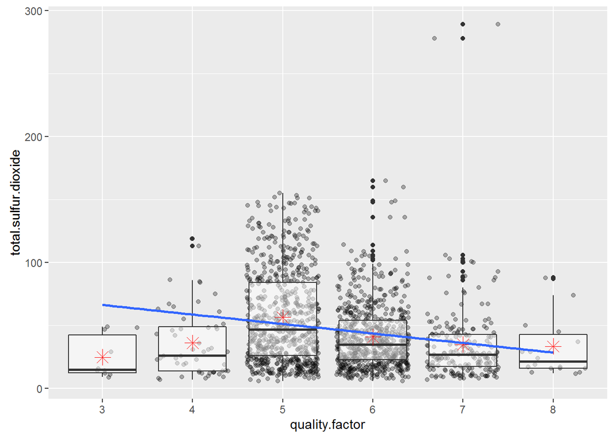

```
## [1] -0.1851003
```

The scatterplot for total sulfur dioxide is interesting because the boxplots for the bad wines (quality values of 3 and 4) are similar to those for the good wines (7 and 8). When we look at wines with quality of 5 or above, the correlation between total sulfur dioxide and quality has r = -0.25. This might be interesting to follow up on later in the investigation.

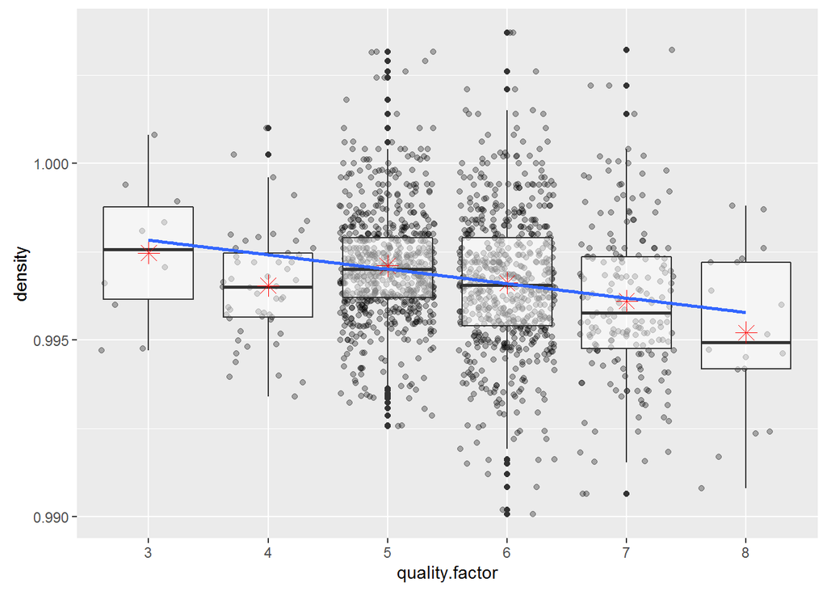

```
## [1] -0.1749192
```

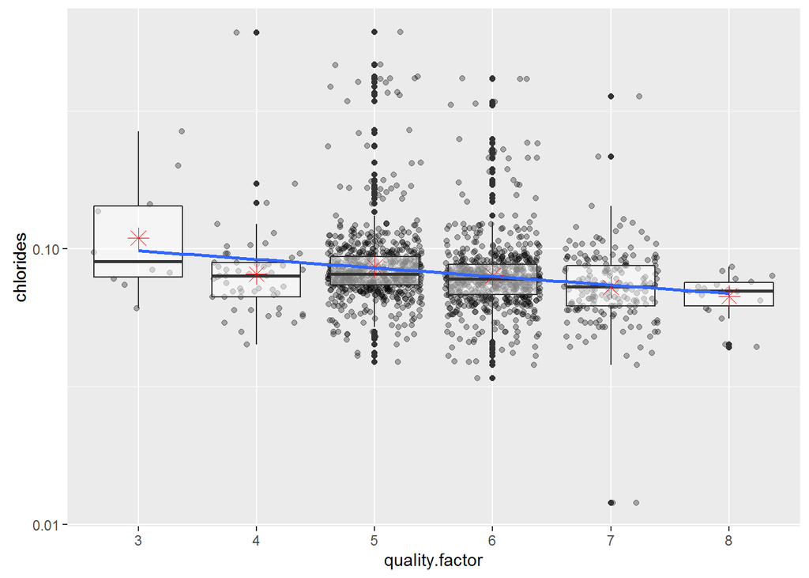

```
## [1] -0.1289066
```

The scatterplot for chlorides supports what was observed on the histogram. The vast majority of values reside close to the median, and then the distribution has long tails. This is particularly true for wines with quality 5,6 and 7. Interestingly, the very good wines (rated 8) have much closer chloride values.

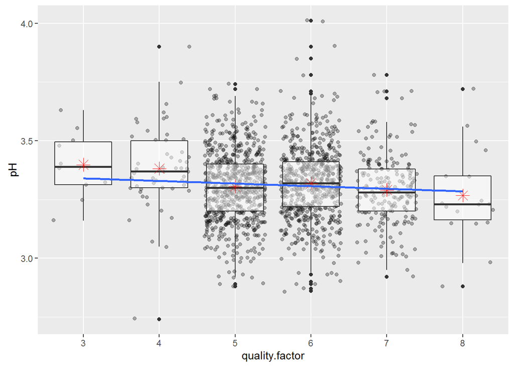

```
## [1] -0.05773139
```

The pH scatterplot show that good wines are slightly more acidic, but this relationship is weak with r = 0.06.

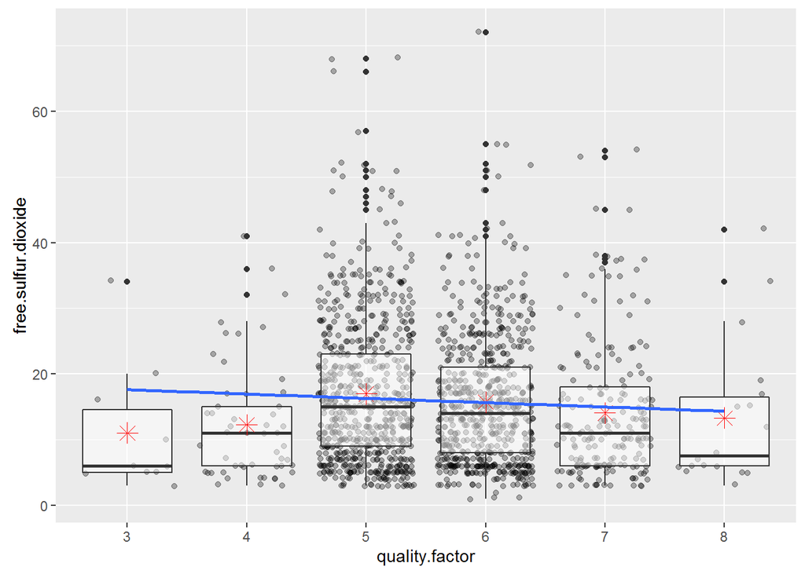

```
## [1] -0.05065606
```

The scatterplot for free sulfur dioxide is similar to that for total sulfur dioxide. We see a striking similarity between the free sulfur dioxide contents of wines rated 3 and 8.

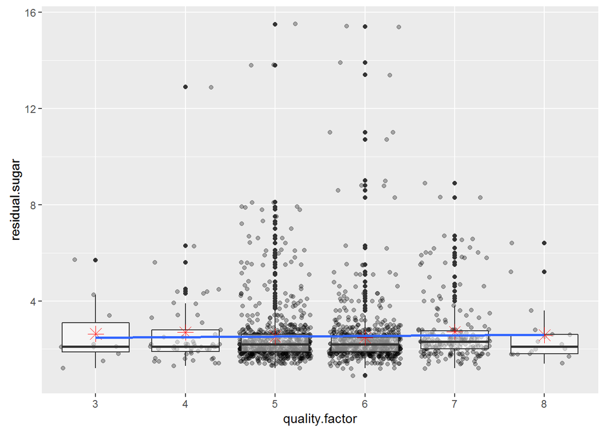

```
## [1] 0.01373164
```

Residual sugar does not correlate with the quality of a wine.

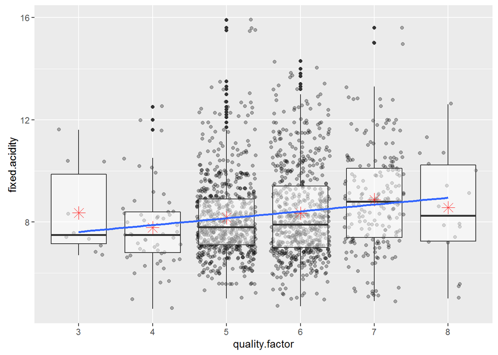

```
## [1] 0.1240516
```

There is a weak correlation between fixed acidity and quality. I’m surprised to see the similarity in the boxplots for wines rated 3 and wines rated 8.

## Other Relationships

Let’s begin by looking at density. The correlation coefficient in included beneath each figure.

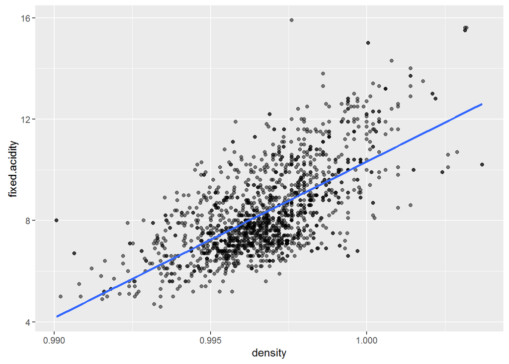

```
## [1] 0.6680473
```

Fixed acidity and density are strongly and positively correlated with r = 0.67.

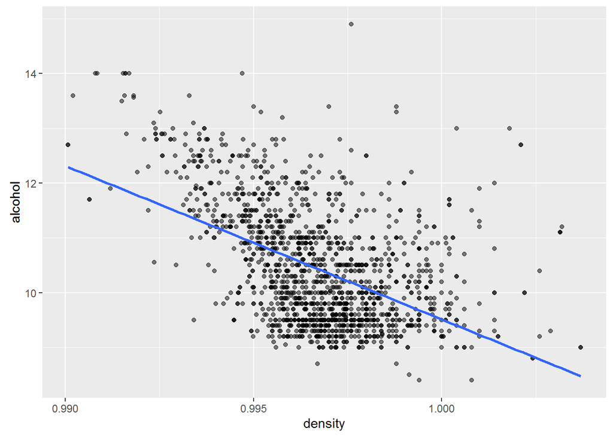

```
## [1] -0.4961798
```

Alcohol and density are negatively correlated with r = -0.50.

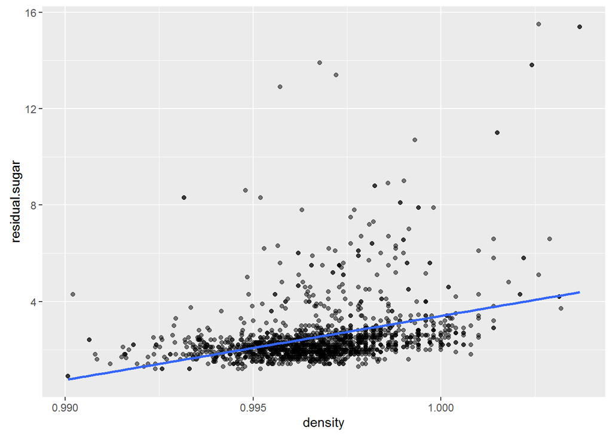

```
## [1] 0.3552834
```

Residual sugar and density are moderately and positively correlated with r = 0.36.

In the multivariate analysis, it will be interesting to add the quality rating as colour to these plots.